# Week 4 Part 1

Ruby Harris-Gavin

11/9/2020

## PART 1

## 1. Confidence intervals

```r
otter_length <- c(38, 41, 50, 27, 32, 41, 48, 60, 43)

t.test(otter_length)
```

```
##
##  One Sample t-test
##
## data:  otter_length
## t = 12.932, df = 8, p-value = 1.21e-06
## alternative hypothesis: true mean is not equal to 0
## 95 percent confidence interval:
##  34.69302 49.75142
## sample estimates:
## mean of x
##  42.22222
```

That’s what this is saying - but when you look at the first part of the data, it is running this on a null value equal to 0. Obviously it is extremely unlikely that otter length of a random sample is 0.

## 2. T-test (1-sample t-test)

See a claim: mean otter length is 50 inches I want to change the null hypothesis to equal 50, not 0.

```r
otter_test <- t.test(x = otter_length, mu = 50)
otter_test
```

```
##
##  One Sample t-test
##
## data:  otter_length
## t = -2.3821, df = 8, p-value = 0.0444
## alternative hypothesis: true mean is not equal to 50
## 95 percent confidence interval:
##  34.69302 49.75142
## sample estimates:
## mean of x
##  42.22222
```

SO what does 0.0444 mean? If the pop mean really is 50 inches, then there is a 4.44% chance that we could have taken a random sample from the population that has a mean that is at least as different from 50 as it is from our sample in either direction.

## Two-sample t-test

```r
desert_bighorns <- c(32, 44, 18, 26, 50, 33, 42, 20)
sierra_bighorns <- c(28, 31, 40, 42, 26, 29, 31)

t.test(x = desert_bighorns, y = sierra_bighorns)
```

```
##
##  Welch Two Sample t-test
##
## data:  desert_bighorns and sierra_bighorns
## t = 0.14825, df = 10.913, p-value = 0.8849
## alternative hypothesis: true difference in means is not equal to 0
## 95 percent confidence interval:
##  -9.653212 11.046069
## sample estimates:
## mean of x mean of y
##  33.12500  32.42857
```

This uses a Welch’s two sample t-test, which doesn’t assume variance

## PART 2

Exploring distributions and mean comparison

```r
compact_suv <- mpg %>%
  filter(class %in% c("compact","suv"))
```

### Exploratory data visualization

Exploratory histograms:

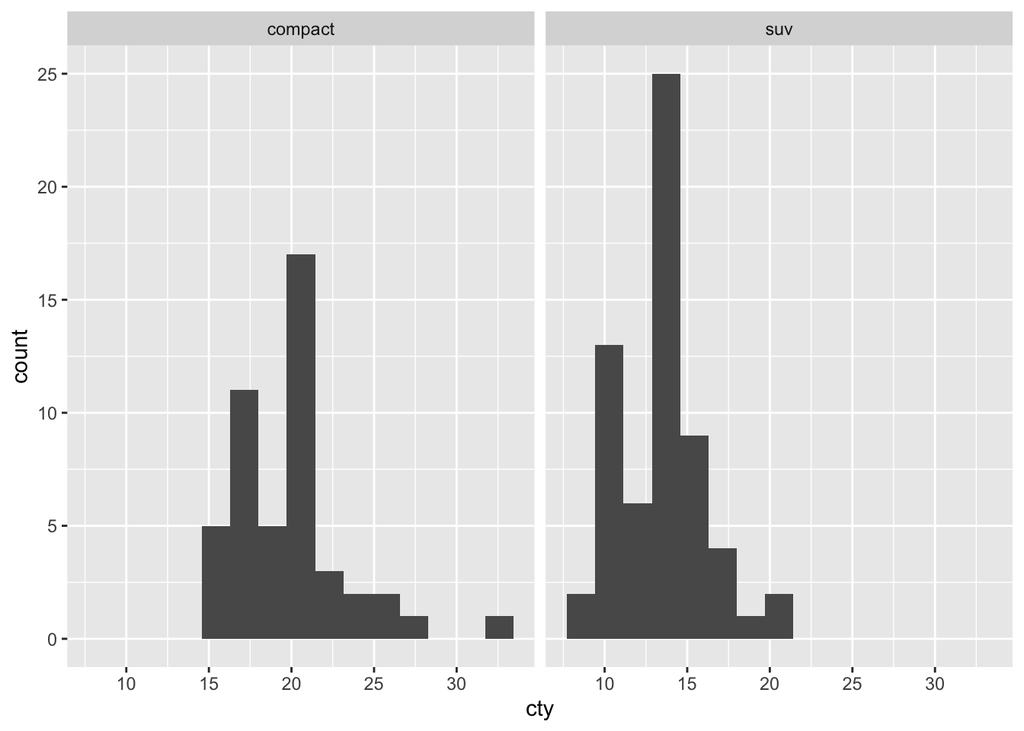

```r
ggplot(data = compact_suv, aes(x = cty)) +
  geom_histogram(bins = 15) +
  facet_wrap(~class)
```

Now we’re going to check out a quantile-quantile plot = the close this relationship is to linear, the closer my samples are to being normally distributed

### Quantile-quantile (QQ) plot

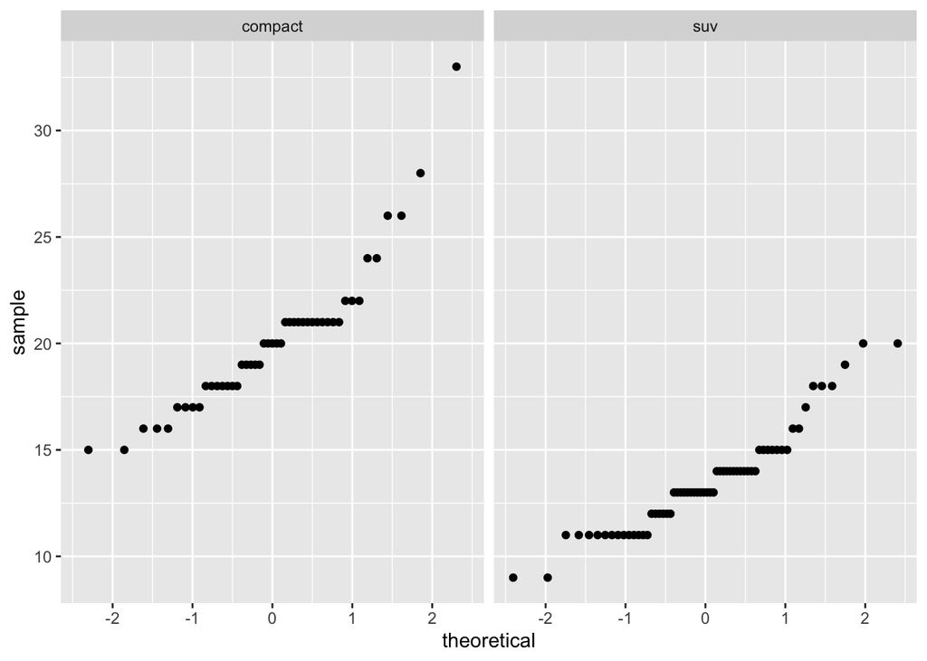

```r
ggplot(data = compact_suv, aes(sample = cty)) +
  geom_qq () +
  facet_wrap(~class)
```

Next, we’re going to find some descriptive summary statistics

```r
car_stats <- compact_suv %>%
  group_by(class) %>%
  summarize(mean_city = mean(cty),
            sd_city = sd(cty),
            n = n())
```

Why do we care about sample size? We know as long as the sample size is greater than 30, and because of the central limit theorem, we know the distribution can be normal and we can use a two sample t-test to compare means.

### 2-sample t-test

Create vectors containing observations for each sample (city gas mileage)

```r
compact_sample <- compact_suv %>%
  filter(class == "compact") %>%
  pull(cty)

suv_sample <- compact_suv %>%
  filter(class == "suv") %>%
  pull(cty)

t.test(x = compact_sample, y = suv_sample)
```

```
##
##  Welch Two Sample t-test
##
## data:  compact_sample and suv_sample
## t = 11.393, df = 79.558, p-value < 2.2e-16
## alternative hypothesis: true difference in means is not equal to 0
## 95 percent confidence interval:
##  5.469914 7.785405
## sample estimates:
## mean of x mean of y
##  20.12766  13.50000
```

Why couldn’t I use select and choose this column instead of pull? It would only store it as a variable, not a vector of values (which the t-test wants)

So what did we learn - the difference between means is pretty big.

Next, null hypothesis is that these samples are drawn from populations with the exact same mean.

Our alt. hypothesis is that the samples are drawn from pops with different means.

And the p-value is SO small that we can say there is an incredibly small chance that we could have randomly taken samples from two populations with the same mean and end up with samples at least as different as this.

So we can reject the null hypothesis!